# Utah Lake CHLA Methods Comparison (2017): Ver 2.0

T.Hooker

30 January, 2018

```r
#packge.set <- c("knitr", "rmarkdown", "plyr", "openxlsx", "lubridate", "htmlTable",
#                "reshape2", "tidyr", "formatR", "xtable", "dplyr")
#lapply(packge.set, library, character.only=T)
#options(table_counter=FALSE)
options(scipen = 999, digits = 4)
#opts_chunk$set(tidy=TRUE)
##
#startwork.date <- format(Sys.Date(), "%y%m%d")
```

### Notes

Notebook describes import and review of CHLA results and associated metadata fior 2017 methods comparison of Utah Lake waters

- 170927 :: Initial Project Start Date
- 171010 :: *Updated UPHL EDDs*

**Next Steps:** [as of 171010] ::

- Add Sampling Dates to Evaluation (Sec. 1.32)
- Adjust MLIDs (4917388 & 4917390 can be combined) [*done*]
- Drop EQBK (equipment blank) from figures / calculations [*done*]
- Keep looking for new CTF data
- 171014 :: *Updated CTF and UPHL data*
- 171023 :: *Update UPHL [edd] data*
- 171109 :: *Update UPHL [edd] data*
- 171208 :: *Update UPHL [edd] data*
  - Email Ed-H and Alia about missing records
- 180103 :: *Update UPHL [edd] & CTF data*
- 180117 :: *Update UPHL [edd] data*
- 180130 :: *Imported CTF-EDDs & Updated Field-Vols*
- 180213 :: *Received last UPHL EDD [?]*

### 1.0 Data Import

**This is an updated version of Utah Lake CHLA method comparison project (180130). Data-preparation steps from previous versions is simplified here, since a great deal of completeness review has already been performed. Field filtration-volumes have been updated and EDDs from CTF have been received and compiled (in another project: “ChemTech_compile_r”).**

#### 1.1 Site Data

Import General site information, including names, coordinates and site type

- This list was updated (in the XLS file) to include site-4917388 (171003)

```r
#UTCH_sites1 <- choose.files(caption="Select _working_ DATA file [*.xlsx]", multi = FALSE)
#UL.sites <- openxlsx::read.xlsx(UTCH_sites1, sheet="Sites", startRow = 1, colNames=TRUE, rowNames=FALSE)
# control digits ib lat/lon
UL.sites$LATNAD83DD <- format(UL.sites$LATNAD83DD, digits=5)
UL.sites$LONNAD83DD <- format(UL.sites$LONNAD83DD, digits=5)
```

This project involves (14) sites associated with Utah Lake open waters, including (2) QC sites

```r
htmlTable::htmlTable(UL.sites[-1], css.cell = rbind(rep("padding-left: 0.7em; padding-right: 0.7em;font-size: 0.7em;", times=ncol(UL.sites)-1), matrix("padding-left: 0.7em; padding-right: 0.7em; font-size: 0.65em;",ncol=ncol(UL.sites)-1, nrow=nrow(UL.sites))), rnames=FALSE)
```

| MLID | Site.Name | GeoF.SiteName | Site.Type | NAD83UTM_X | NAD83UTM_Y | LONNAD83DD | LATNAD83DD | AU_name |
| --- | --- | --- | --- | --- | --- | --- | --- | --- |
| 4917310 | UTLK 0.5 mi W Geneva Disch #15A | UTAH LAKE 0.5 MI W OF GENEVA DISCHARGE #15-A | Lake | 433941 | 4463662 | -111.78 | 40.321 | Utah Lake |
| 4917320 | Replicate 4917310 | UTAH LAKE 0.5 MI W OF GENEVA DISCHARGE #15-B (4917310 Duplicate) | QC | 433941 | 4463662 | -111.78 | 40.321 | Utah Lake |
| 4917365 | UTLK 2mi W Vineyard; EXO | Utah Lake 2 miles west of Vineyard | Lake | 431768 | 4460886 | -111.80 | 40.296 | Utah Lake |
| 4917370 | UTLK 1mi E Pelican Pt | UTAH LAKE 1 MI EAST OF PELICAN POINT | Lake | 429435 | 4457865 | -111.83 | 40.268 | Utah Lake |
| 4917388 | UTLK 0.5mi W Provo Bay; EXO | Utah Lake 1.5 miles west of Uah Lake State Park HQ building | Lake | 434699 | 4454443 | -111.77 | 40.238 | Utah Lake |
| 4917390 | UTLK 0.5mi W Provo Bay | UTAH LAKE 1 MI WEST OF PROVO BOAT HARBOR | Lake | 434956 | 4454362 | -111.76 | 40.237 | Utah Lake |
| 4917450 | UTLK @Middle Provo Bay | UTAH LAKE AT MIDDLE OF PROVO BAY | Lake | 440419 | 4448985 | -111.70 | 40.189 | Utah Lake |
| 4917500 | UTLK 3mi WNW Lincoln Bch | UTAH LAKE 3 MI WNW OF LINCOLN BEACH | Lake | 425784 | 4446954 | -111.87 | 40.170 | Utah Lake |
| 4917520 | UTLK 2mi E Saratoga Spr #12 | UTAH LAKE 2 MI E OF SARATOGA SPRINGS #12 | Lake | 425996 | 4466100 | -111.87 | 40.342 | Utah Lake |
| 4917600 | UTLK @Goshen SW | UTAH LAKE GOSHEN BAY SOUTHWEST END | Lake | 425428 | 4434809 | -111.87 | 40.060 | Utah Lake |
| 4917710 | UTLK 1mi NE Lincoln Pt#03 | UTAH LAKE 1 MI NE OF LINCOLN POINT #03 | Lake | 432608 | 4445564 | -111.79 | 40.158 | Utah Lake |
| 4917715 | UTLK 1mi E of Bird Isl; EXO | UTAH LAKE OUTSIDE ENTRANCE TO PROVO BAY | Lake | 437747 | 4448943 | -111.73 | 40.189 | Utah Lake |
| 4917770 | UTLK Outside Provo Bay | Utah Lake 1 mile southeast of Bird Island | Lake | 433815 | 4446823 | -111.78 | 40.169 | Utah Lake |
| 4930009 | Equipment Blank | Clean Lakes equipment blank Vertigrator | QC | 420009 | 4514116 | -111.95 | 40.774 | Clean.Lakes |

```r
# vector of sites for UTLk project
UTLake.mlid <- sort(unique(UL.sites$MLID))
```

#### 1.15 Filtered Volumes

**All filtered Volume observations are located in the Field Data**

#### 1.2 Field Obs

```r
#UTCH_sites1 <- choose.files(caption="Select _working_ DATA file [*.xlsx]", multi = FALSE)
UL.field <- openxlsx::read.xlsx(UTCH_sites1, sheet="Field.dat.OW", startRow = 3, colNames=TRUE, rowNames=FALSE);

####
#   Need to fix Sample Dates and Times [format]
####
# date format is MSExcel Time
UL.field$SDate <- as.Date(UL.field$SDate, origin = "1899-12-30")
x0 <- UL.field$Time
x1 <- x0 - as.integer(x0)
UL.field$Time <- format(as.POSIXct(Sys.Date() + x1), "%H:%M", tz="UTC")
UL.field$month <- (format(UL.field$SDate, "%b"))
UL.field$month_n <- as.integer(format(UL.field$SDate, "%m"))
#
```

```r
fld.tab1 <- as.data.frame.matrix((table(UL.field$MLID, UL.field$month_n, useNA = "ifany", deparse.level = 2)))
mlid <- rownames(fld.tab1)
fld.tab1 <- cbind(mlid, fld.tab1)
names(fld.tab1)[2:7] <- month.abb[as.integer(names(fld.tab1)[2:7])]
rownames(fld.tab1) <- NULL
htmlTable::htmlTable(fld.tab1, css.cell = rbind(rep("padding-left: 0.7em; padding-right: 0.9em;font-size: 0.8em;", times=ncol(fld.tab1)), matrix("padding-left: 0.8em; padding-right: 0.8em; font-size: 0.8em;",ncol=ncol(fld.tab1), nrow=nrow(fld.tab1))), rnames=FALSE, caption = "Field records by Month")
```

| Field records by Month mlid | Field records by Month May | Field records by Month Jun | Field records by Month Jul | Field records by Month Aug | Field records by Month Sep | Field records by Month Oct | Field records by Month 11 |
| --- | --- | --- | --- | --- | --- | --- | --- |
| 4917310 | 1 | 1 | 1 | 1 | 1 | 1 | 1 |
| 4917320 | 1 | 1 | 1 | 1 | 1 | 1 | 1 |
| 4917365 | 1 | 1 | 1 | 1 | 1 | 1 | 1 |
| 4917370 | 1 | 1 | 1 | 1 | 1 | 1 | 1 |
| 4917390 | 1 | 1 | 1 | 1 | 1 | 1 | 1 |
| 4917450 | 1 | 1 | 1 | 1 | 1 | 1 | 1 |
| 4917500 | 1 | 1 | 1 | 1 | 1 | 1 | 1 |
| 4917520 | 1 | 1 | 1 | 1 | 1 | 1 | 1 |
| 4917600 | 1 | 1 | 1 | 1 | 1 | 1 | 1 |
| 4917710 | 1 | 1 | 1 | 1 | 1 | 1 | 1 |
| 4917715 | 1 | 1 | 1 | 1 | 1 | 1 | 1 |
| 4917770 | 1 | 1 | 1 | 1 | 1 | 1 | 1 |
| 4930009 | 1 | 1 | 1 | 1 | 1 | 1 | 1 |

- **Field record for May, site 4917390 is synonymous with 4917388**
- **Site 4917320 is a Field-Replicate of 4917310**
- **Site 4930009 an an Equipment Blank - Not used as part of this method-comparison project**

*Compile Field-data Vols*

```r
fld.vols_melt <- reshape2::melt(UL.field[,c("MLID", "SDate", "month", "CHLA.vol")],
                                id.vars = c("MLID", "SDate", "month"),
                                value.name = "CHLA.vol")
fld.vols_melt$month_n <- plyr::revalue(fld.vols_melt$month, c("May" = 5, "Jun" = 6,
                                    "Jul" = 7, "Aug" = 8, "Sep" = 9, "Oct" = 10, "Nov" = 11))
```

#### 1.3 Filtration Volume

All volume records from Utah Lake “field data”

```r
FILT.vols <- fld.vols_melt
FILT.vols$month_n <- as.integer(FILT.vols$month_n)
```

**Filtered Volume Dataframe** :: `FILT.vols` + Var == “CHLA.vol”

*Summary of Volume Measurements*

```r
tab1 <- as.data.frame.matrix(addmargins(table(FILT.vols$MLID[!is.na(FILT.vols$CHLA.vol)], FILT.vols$month[!is.na(FILT.vols$CHLA.vol)], useNA = "ifany", deparse.level = 2)))
tab1$MLID <- rownames(tab1)
tab1 <- dplyr::select(tab1, MLID, May, Jun, Jul, Aug, Sep, Oct, Nov, Sum)
row.names(tab1) <- NULL
tab1$comment[tab1$MLID == "4930009"] <- "EQ BLK"
tab1$comment[tab1$MLID == "4917320"] <- "Field Rep. of 4917310"
tab1$comment[tab1$MLID == "4917390"] <- "syn. w/ 4917388"
# styling for missing / zero's (0)
tabdat <- tab1
css.cell <- matrix("", nrow=nrow(tabdat)+1, ncol=ncol(tabdat))
cellbold <- matrix("", nrow=nrow(tabdat)+1, ncol=ncol(tabdat))
css.x <- matrix("", nrow=nrow(tabdat)+1, ncol=ncol(tabdat))
for (i in 2:(nrow(cellbold))) {
    for (j in 1:ncol(cellbold)-1) {
        cellbold[i,j] <- ifelse(is.na(tabdat[i-1,j]), "font-weight: 700;background: gray90; border: 1px solid;",
            ifelse(tabdat[i-1,j] == 0, "font-weight: 700;background: #DCDCDC; border: 1px solid;", ""))     }   }
css.cell = rbind(rep("padding-left: 0.7em; padding-right: 0.9em;font-size: 0.8em;", times=ncol(tabdat)), matrix("padding-left: 0.8em; padding-right: 0.8em; font-size: 0.8em;",ncol=ncol(tabdat), nrow=nrow(tabdat)))
for (i in 1:nrow(cellbold)) {
    for (j in 1:ncol(cellbold)) {
        css.cell[i,j] <- paste(css.cell[i,j], cellbold[i,j])  }   }
#
htmlTable::htmlTable(tab1, css.cell = css.cell, caption = "Samples with Filtration Volume by Month", rnames=FALSE, total = TRUE)
```

| Samples with Filtration Volume by Month MLID | Samples with Filtration Volume by Month May | Samples with Filtration Volume by Month Jun | Samples with Filtration Volume by Month Jul | Samples with Filtration Volume by Month Aug | Samples with Filtration Volume by Month Sep | Samples with Filtration Volume by Month Oct | Samples with Filtration Volume by Month Nov | Samples with Filtration Volume by Month Sum | Samples with Filtration Volume by Month comment |
| --- | --- | --- | --- | --- | --- | --- | --- | --- | --- |
| 4917310 | 1 | 1 | 1 | 1 | 1 | 1 | 1 | 7 |  |
| 4917320 | 0 | 1 | 1 | 1 | 1 | 0 | 0 | 4 | Field Rep. of 4917310 |
| 4917365 | 1 | 1 | 1 | 1 | 1 | 1 | 1 | 7 |  |
| 4917370 | 1 | 1 | 1 | 1 | 1 | 1 | 1 | 7 |  |
| 4917390 | 1 | 1 | 1 | 1 | 1 | 1 | 1 | 7 | syn. w/ 4917388 |
| 4917450 | 1 | 1 | 1 | 1 | 1 | 1 | 1 | 7 |  |
| 4917500 | 1 | 1 | 1 | 1 | 1 | 1 | 1 | 7 |  |
| 4917520 | 1 | 1 | 1 | 1 | 1 | 1 | 1 | 7 |  |
| 4917600 | 1 | 1 | 1 | 1 | 1 | 1 | 1 | 7 |  |
| 4917710 | 1 | 1 | 1 | 1 | 1 | 1 | 1 | 7 |  |
| 4917715 | 1 | 1 | 1 | 1 | 1 | 1 | 1 | 7 |  |
| 4917770 | 1 | 1 | 1 | 1 | 1 | 1 | 1 | 7 |  |
| 4930009 | 1 | 1 | 1 | 1 | 1 | 1 | 1 | 7 | EQ BLK |
| Sum | 12 | 13 | 13 | 13 | 13 | 12 | 12 | 88 |  |

**Summarize filtration volume: MLID x Date**

```r
FILTvol_cast <- reshape2::dcast(FILT.vols, MLID ~ month_n, value.var = "CHLA.vol", fun.aggregate=function(x) mean(x, na.rm=TRUE))
# annotate table
FILTvol_cast$Note <- NA
FILTvol_cast$Note[2] <- "Field Rep of 4917310; not used"
FILTvol_cast$Note[5] <- "Includes 4917388 [May17]"
FILTvol_cast$Note[13] <- "Equipment Blank; not used"
# prepare table ~css~
tabdat <- FILTvol_cast
css.cell <- matrix("", nrow=nrow(tabdat)+1, ncol=ncol(tabdat))
cellbold <- matrix("", nrow=nrow(tabdat)+1, ncol=ncol(tabdat))
css.x <- matrix("", nrow=nrow(tabdat)+1, ncol=ncol(tabdat))
## highlight the cells in the table missing data (i.e. value = 0)
for (i in 2:(nrow(cellbold))) {
    for (j in 1:ncol(cellbold)-1) {
        cellbold[i,j] <- ifelse(is.na(tabdat[i-1,j]), "font-weight: 700; background: #DCDCDC; border: 1px solid;",
            ifelse(tabdat[i-1,j] == 0, "font-weight: 700; background: gray90; border: 1px solid;", ""))     }   }
#  background: lightgrey;
#  font-weight: 900;
#  border: solid 1px;
css.cell = rbind(rep("padding-left: 0.7em; padding-right: 0.9em;font-size: 0.8em;", times=ncol(tabdat)), matrix("padding-left: 0.8em; padding-right: 0.8em; font-size: 0.8em;",ncol=ncol(tabdat), nrow=nrow(tabdat)))
for (i in 1:nrow(cellbold)) {
    for (j in 1:ncol(cellbold)) {
        css.cell[i,j] <- paste(css.cell[i,j], cellbold[i,j])  }   }
#
htmlTable::htmlTable(FILTvol_cast, css.cell = css.cell, rnames=FALSE, caption = "Filtration Volumes for CHLA samples")
```

| Filtration Volumes for CHLA samples MLID | Filtration Volumes for CHLA samples 5 | Filtration Volumes for CHLA samples 6 | Filtration Volumes for CHLA samples 7 | Filtration Volumes for CHLA samples 8 | Filtration Volumes for CHLA samples 9 | Filtration Volumes for CHLA samples 10 | Filtration Volumes for CHLA samples 11 | Filtration Volumes for CHLA samples Note |
| --- | --- | --- | --- | --- | --- | --- | --- | --- |
| 4917310 | 250 | 450 | 250 | 250 | 350 | 250 | 250 |  |
| 4917320 |  | 450 | 250 | 250 | 350 |  |  | Field Rep of 4917310; not used |
| 4917365 | 250 | 250 | 250 | 250 | 250 | 250 | 250 |  |
| 4917370 | 250 | 350 | 250 | 250 | 250 | 250 | 250 |  |
| 4917390 | 350 | 350 | 250 | 250 | 250 | 250 | 250 | Includes 4917388 [May17] |
| 4917450 | 250 | 200 | 150 | 100 | 150 | 250 | 250 |  |
| 4917500 | 350 | 250 | 150 | 250 | 250 | 250 | 250 |  |
| 4917520 | 350 | 350 | 250 | 250 | 250 | 250 | 250 |  |
| 4917600 | 250 | 150 | 150 | 100 | 100 | 150 | 250 |  |
| 4917710 | 250 | 400 | 400 | 250 | 250 | 250 | 250 |  |
| 4917715 | 250 | 250 | 250 | 250 | 250 | 250 | 250 |  |
| 4917770 | 250 | 250 | 250 | 250 | 250 | 250 | 250 |  |
| 4930009 | 500 | 500 | 500 | 500 | 500 | 250 | 250 | Equipment Blank; not used |

- Note that the site 4917388 is not included in this table
- Site 4917320 is a Field Replicate (of 4917310) for QC purposes only
- Site 4930009 is the Equipment Blank, analyzed only at UPHL, and can be ignored

#### 1.4 Sample Dates

```r
addmargins(table(UL.field$SDate, UL.field$month_n, useNA = "ifany"))
```

```
              5  6  7  8  9 10 11 Sum
  2017-05-10  6  0  0  0  0  0  0   6
  2017-05-11  7  0  0  0  0  0  0   7
  2017-06-15  0 12  0  0  0  0  0  12
  2017-06-16  0  1  0  0  0  0  0   1
  2017-07-11  0  0 13  0  0  0  0  13
  2017-08-07  0  0  0  4  0  0  0   4
  2017-08-08  0  0  0  9  0  0  0   9
  2017-09-11  0  0  0  0 13  0  0  13
  2017-10-10  0  0  0  0  0  1  0   1
  2017-10-16  0  0  0  0  0 11  0  11
  2017-10-17  0  0  0  0  0  1  0   1
  2017-11-08  0  0  0  0  0  0 13  13
  Sum        13 13 13 13 13 13 13  91
```

- Sampling Dates for MLIDs by month (*from Field Data*)

```r
tab.set <- data.frame()
for (i in unique(UL.field$month_n)) {
    t_i <- table(UL.field$MLID[UL.field$month_n == i], UL.field$SDate[UL.field$month_n == i])
    tab.set <- rbind(tab.set, t_i)
    print(t_i)  }
```

[output not shown]

#### 1.5 UPHL Lab Data

**Compile Data from UPHL EDDs**

- First EDD date for Utah Lake CHL project :: 8/1/2017
- EDD file list updated 171010 [for EDDs through 171006]
- Updates 171023 [for EDDs through 171020]
- Updates 171109 (additional EDDs)
- Updated 180103 (additional EDDs)
- Updated 180117 (additional EDDs)
- Updated 180212 (last remaining EDD ?)

```r
# files.lab <- choose.files(caption="Select DATA files [*.txt]", multi = TRUE)
b <- lapply(files.lab, FUN=read.delim, as.is=TRUE, header=TRUE)
filename <- basename(files.lab)
names(b) <- filename
path.filename <- dirname(files.lab)
```

A total of 36 data files were selected from path: **K:/WQX/processed**

```r
options(width=95)
file.list <- filename
length(file.list) <- prod(dim(matrix(file.list, ncol=3)))
filelist.dat <- data.frame(matrix(data=(file.list), ncol=3, byrow=TRUE))
htmlTable::htmlTable(filelist.dat, caption = "Names of imported data files", css.cell = rbind(rep("padding-left: 1em; padding-right: 1em;font-size: 0.8em;", times=ncol(filelist.dat)), matrix("padding-left: 0.8em; padding-right: 0.8em; font-size: 0.8em;", ncol=ncol(filelist.dat), nrow=nrow(filelist.dat))), align="l", header = rep(NA, times = ncol(filelist.dat)))
```

| Names of imported data files | Names of imported data files | Names of imported data files | Names of imported data files |
| --- | --- | --- | --- |
| 1 | UDWQ_EDD_20180209.txt | UDWQ_EDD_20180205-2.txt | UDWQ_EDD_20180205.txt |
| 2 | UDWQ_EDD_20180129.txt | UDWQ_EDD_20180126.txt | UDWQ_EDD_20180119.txt |
| 3 | UDWQ_EDD_20180112.txt | UDWQ_EDD_20180112_091410.txt | UDWQ_EDD_20180105_122457.txt |
| 4 | UDWQ_EDD_20180105.txt | UDWQ_EDD_20180103.txt | UDWQ_EDD_20180103_090758.txt |
| 5 | UDWQ_EDD_20171222.txt | UDWQ_EDD_20171215.txt | UDWQ_EDD_20171208.txt |
| 6 | UDWQ_EDD_20171201.txt | UDWQ_EDD_20171124.txt | UDWQ_EDD_20171117.txt |
| 7 | UDWQ_EDD_20171109.txt | UDWQ_EDD_20171103.txt | UDWQ_EDD_20171103_092918.txt |
| 8 | UDWQ_EDD_20171020.txt | UDWQ_EDD_20171013.txt | UDWQ_EDD_20171006.txt |
| 9 | UDWQ_EDD_20170929.txt | UDWQ_EDD_20170922.txt | UDWQ_EDD_20170915.txt |
| 10 | UDWQ_EDD_20170901.txt | UDWQ_EDD_20170901_092150.txt | UDWQ_EDD_20170825.txt |
| 11 | UDWQ_EDD_20170818.txt | UDWQ_EDD_20170817.txt | UDWQ_EDD_20170816.txt |
| 12 | UDWQ_EDD_20170815.txt | UDWQ_EDD_20170811.txt | UDWQ_EDD_20170801.txt |

**Identify Files that contain CHLA data**

```r
# extract all methods
EDD_method <- data.frame()
for (i in 1:length(b)) {
    EDD_method <- rbind(EDD_method,
        data.frame(file = i, Filename = names(b[i]),
            Num.methods = length(unique(b[[i]]$Method.Description)),
            Methods = sort(unique(trimws(b[[i]]$Method.Description)))))   }
# extract all methods from EDDs
EDD_method.df <- data.frame(EDD.Methods = sort(unique(EDD_method$Methods)))
# get CHLA-related method(s)
CHL.meth <- c("SM 10200H Chlorophyll with Pheophytin and Chlorophyll After Acid")
#
```

```r
htmlTable::htmlTable(EDD_method.df, css.cell = "padding-left: 0.8em; padding-right: 0.8em; font-size: 0.65em;", align="l", rnames=FALSE)
```

[output not shown]

```r
EDD_meta1 <- data.frame()
for (i in 1:length(b)) {
    EDD_meta1 <- rbind(EDD_meta1,
        data.frame(n = i, File.name = names(b[i]), n_recs = nrow(b[[i]]),
            min_SDate = min(as.Date(b[[i]]$Sample.Date,format = "%m/%d/%Y")),
            max_SDate = max(as.Date(b[[i]]$Sample.Date,format = "%m/%d/%Y")),
            UTL.recs = length(b[[i]]$Station.ID[b[[i]]$Station.ID %in% UTLake.mlid]),
            UTL.sites = length(unique(b[[i]]$Station.ID[b[[i]]$Station.ID %in% UTLake.mlid])),
            UTL.CHLA.sites = length(unique(b[[i]]$Station.ID[b[[i]]$Station.ID %in% UTLake.mlid & b[[i]]$Method.Description %in% CHL.meth])))  )   }
#
TOT <- as.data.frame(cbind(NA, "Totals", sum(EDD_meta1[,3], na.rm=T), NA, NA, sum(EDD_meta1[,6], na.rm=T), sum(EDD_meta1[,7], na.rm=T), sum(EDD_meta1[,8], na.rm=T)))
names(TOT) <- names(EDD_meta1)
EDD_meta2 <- rbind(EDD_meta1, TOT)
# truncate to only records w/ UTL results
EDD_meta3 <- EDD_meta2[EDD_meta2$UTL.recs > 0,]
```

```r
htmlTable::htmlTable(EDD_meta3, css.cell = rbind(rep("padding-left: 0.8em; padding-right: 0.8em;font-size: 0.7em;", times=ncol(EDD_meta3)), matrix("padding-left: 0.75em; padding-right: 0.75em; font-size: 0.7em;", ncol=ncol(EDD_meta3), nrow=nrow(EDD_meta3))), rnames=FALSE, align=c("c","l","c"), caption = "Occurrence of UT Lake results in UPHL-EDDs", total = TRUE)
```

| Occurrence of UT Lake results in UPHL-EDDs n | Occurrence of UT Lake results in UPHL-EDDs File.name | Occurrence of UT Lake results in UPHL-EDDs n_recs | Occurrence of UT Lake results in UPHL-EDDs min_SDate | Occurrence of UT Lake results in UPHL-EDDs max_SDate | Occurrence of UT Lake results in UPHL-EDDs UTL.recs | Occurrence of UT Lake results in UPHL-EDDs UTL.sites | Occurrence of UT Lake results in UPHL-EDDs UTL.CHLA.sites |
| --- | --- | --- | --- | --- | --- | --- | --- |
| 2 | UDWQ_EDD_20180205-2.txt | 141 | 2017-06-15 | 2017-08-07 | 141 | 2 | 2 |
| 3 | UDWQ_EDD_20180205.txt | 1031 | 2018-01-03 | 2018-01-24 | 5 | 1 | 0 |
| 5 | UDWQ_EDD_20180126.txt | 2962 | 2017-12-04 | 2018-01-04 | 8 | 1 | 1 |
| 9 | UDWQ_EDD_20180105_122457.txt | 4000 | 2017-10-24 | 2017-11-13 | 866 | 13 | 12 |
| 12 | UDWQ_EDD_20180103_090758.txt | 4000 | 2017-07-18 | 2017-10-30 | 836 | 11 | 11 |
| 13 | UDWQ_EDD_20171222.txt | 3102 | 2017-07-19 | 2017-11-29 | 24 | 1 | 1 |
| 15 | UDWQ_EDD_20171208.txt | 1666 | 2017-10-11 | 2017-10-23 | 59 | 1 | 0 |
| 17 | UDWQ_EDD_20171124.txt | 1188 | 2017-10-02 | 2017-10-30 | 69 | 1 | 1 |
| 19 | UDWQ_EDD_20171109.txt | 2849 | 2017-03-21 | 2017-10-31 | 484 | 8 | 8 |
| 20 | UDWQ_EDD_20171103.txt | 1650 | 2017-09-07 | 2017-10-19 | 43 | 3 | 1 |
| 21 | UDWQ_EDD_20171103_092918.txt | 4000 | 2017-06-22 | 2017-09-12 | 1484 | 12 | 12 |
| 24 | UDWQ_EDD_20171006.txt | 1403 | 2017-07-24 | 2017-09-26 | 18 | 1 | 0 |
| 25 | UDWQ_EDD_20170929.txt | 3112 | 2017-06-01 | 2017-09-27 | 213 | 4 | 4 |
| 27 | UDWQ_EDD_20170915.txt | 1407 | 2017-07-06 | 2017-07-19 | 341 | 5 | 4 |
| 29 | UDWQ_EDD_20170901_092150.txt | 4000 | 2017-04-25 | 2017-07-13 | 278 | 4 | 4 |
| 30 | UDWQ_EDD_20170825.txt | 1775 | 2017-06-13 | 2017-08-17 | 367 | 8 | 5 |
| 31 | UDWQ_EDD_20170818.txt | 1950 | 2017-05-23 | 2017-08-14 | 47 | 13 | 1 |
| 32 | UDWQ_EDD_20170817.txt | 4000 | 2016-08-09 | 2017-06-26 | 31 | 5 | 1 |
| 33 | UDWQ_EDD_20170816.txt | 4000 | 2017-05-17 | 2017-06-13 | 29 | 1 | 1 |
| 34 | UDWQ_EDD_20170815.txt | 4000 | 2017-05-13 | 2017-05-25 | 26 | 1 | 1 |
| 35 | UDWQ_EDD_20170811.txt | 4000 | 2017-05-02 | 2017-05-17 | 870 | 13 | 12 |
|  | Totals | 83297 |  |  | 6239 | 109 | 82 |

**UPHL Lab Data Cleanup**

*Extract Utah Lake records (by MLID)*

```r
# extract results from EDD-list (b)
EDD.dat0 <- plyr::ldply(b, .id="Lab.filename")
## add MLID (as CHAR) to DF
EDD.dat0$MLID.c <- as.character(EDD.dat0$Station.ID)
# Subet for Utah Lake MLIDs (in list)
UTLK_uphl <- EDD.dat0[EDD.dat0$Station.ID %in% UTLake.mlid,]
row.names(UTLK_uphl) <- NULL
# correct sample date format
UTLK_uphl$Sample.Date <- as.Date(lubridate::parse_date_time(UTLK_uphl$Sample.Date, "mdy HMS", truncated=3))
# convert Sample.Date to XLS time and creak Sample-Key-1 (as SK1)
UTLK_uphl$SDate <- as.numeric(as.Date(UTLK_uphl$Sample.Date) - as.Date(0, origin="1899-12-30", tz='UTC'))
# Sample key 1
UTLK_uphl$SK1 <- paste(UTLK_uphl$Station.ID, UTLK_uphl$SDate, sep=".")
```

*UPHL Data Summary [Utah Lake Records]*

- Number of Records: [6,239]
- Number of unique **Sites**: [14]
- Number of **Sampling Dates**: [41]
  - From: [2016-09-20]
  - To: [2018-01-10]
- Number of **Sampling Events**: [55]
- Number of unique parameter levels: [44]
- Note that these results (above) include all parameters and some additional Non-UTLK samples collected as part of the DWQ-Lakes program

**Subset for only Chlorophyll-related records**

```r
ULCHL.dat0 <- UTLK_uphl[UTLK_uphl$Method.Description %in% CHL.meth,]
row.names(ULCHL.dat0) <- NULL
ULCHL.dat0$month <- as.integer(format(ULCHL.dat0$Sample.Date, "%m"))
```

*UPHL CHLA-Data Summary [Utah Lake Records]*

- Number of Records: [795]
- Number of unique **Sites**: [14]
- Number of **Sampling Dates**: [34]
  - From: [2017-05-10]
  - To: [2017-12-20]
- Number of **Sampling Events**: [48]
- Number of unique parameters: [3]
  - Chlorophyll-A After Acid // Chlorophyll-A Before Acid // Pheophytin

```r
tab2 <- as.data.frame.matrix(addmargins(table(ULCHL.dat0$Station.ID, ULCHL.dat0$month, useNA = "ifany", deparse.level = 2, exclude = c("12"))))
tab2$MLID <- rownames(tab2)
tab2 <- tab2[,c(ncol(tab2),1:(ncol(tab2)-1))]
rownames(tab2) <- NULL
# Number of Utah Lake CHLA-related records by month of sampling
# Table values are in triplicate, for the 3 parameters listed above
# add BOLD for missing results, add 1 to ROW for Headers
#
## Add notations for some MLIDs
tab2$note <- ""
tab2$note[tab2$MLID == "4917388"] <- "combined w/ 4917390"
tab2$note[tab2$MLID == "4917320"] <- "replicate of 4917310"
tab2$note[tab2$MLID == "4930009"] <- "EQ Blank, needs further refinement"
#
tabdat <- tab2
css.cell <- matrix("", nrow=nrow(tabdat)+1, ncol=ncol(tabdat))
cellbold <- matrix("", nrow=nrow(tabdat)+1, ncol=ncol(tabdat))
css.x <- matrix("", nrow=nrow(tabdat)+1, ncol=ncol(tabdat))
for (i in 2:(nrow(cellbold))) {
    for (j in 1:ncol(cellbold)) {
        cellbold[i,j] <- ifelse(is.na(tabdat[i-1,j]), "font-weight: 700;background: gray90;border: 1px solid;",
            ifelse(tabdat[i-1,j] == 0, "font-weight: 700;background: #DCDCDC; border: 1px solid;", ""))     }   }
css.cell = rbind(rep("padding-left: 0.7em; padding-right: 0.9em;font-size: 0.8em;", times=ncol(tabdat)), matrix("padding-left: 0.8em; padding-right: 0.8em; font-size: 0.8em;",ncol=ncol(tabdat), nrow=nrow(tabdat)))
for (i in 1:nrow(cellbold)) {
    for (j in 1:ncol(cellbold)) {
        css.cell[i,j] <- paste(css.cell[i,j], cellbold[i,j])  }   }
#
htmlTable::htmlTable(tabdat, css.cell = css.cell, caption = "UPHL CHLa results by Month", rnames=FALSE, total = TRUE)
```

| UPHL CHLa results by Month MLID | UPHL CHLa results by Month 5 | UPHL CHLa results by Month 6 | UPHL CHLa results by Month 7 | UPHL CHLa results by Month 8 | UPHL CHLa results by Month 9 | UPHL CHLa results by Month 10 | UPHL CHLa results by Month 11 | UPHL CHLa results by Month Sum | UPHL CHLa results by Month note |
| --- | --- | --- | --- | --- | --- | --- | --- | --- | --- |
| 4917310 | 9 | 9 | 9 | 9 | 9 | 9 | 9 | 63 |  |
| 4917320 | 0 | 0 | 0 | 9 | 0 | 0 | 0 | 9 | replicate of 4917310 |
| 4917365 | 9 | 9 | 9 | 9 | 9 | 9 | 9 | 63 |  |
| 4917370 | 9 | 9 | 9 | 9 | 9 | 9 | 9 | 63 |  |
| 4917388 | 9 | 0 | 0 | 0 | 0 | 0 | 0 | 9 | combined w/ 4917390 |
| 4917390 | 0 | 9 | 9 | 9 | 9 | 9 | 9 | 54 |  |
| 4917450 | 9 | 9 | 9 | 9 | 9 | 9 | 9 | 63 |  |
| 4917500 | 9 | 9 | 9 | 9 | 9 | 9 | 9 | 63 |  |
| 4917520 | 9 | 9 | 9 | 9 | 9 | 9 | 9 | 63 |  |
| 4917600 | 9 | 9 | 9 | 9 | 9 | 9 | 9 | 63 |  |
| 4917710 | 9 | 9 | 9 | 9 | 9 | 9 | 9 | 63 |  |
| 4917715 | 9 | 9 | 9 | 9 | 9 | 9 | 9 | 63 |  |
| 4917770 | 9 | 9 | 9 | 9 | 9 | 9 | 9 | 63 |  |
| 4930009 | 6 | 12 | 9 | 9 | 21 | 24 | 9 | 90 | EQ Blank, needs further refinement |
| Sum | 105 | 111 | 108 | 117 | 120 | 123 | 108 | 792 |  |

**Correct MLID mis-match for 4917388 and 4917390**

```r
# adding Var = MLID, to correct site-id change
ULCHL.dat0$MLID <- ULCHL.dat0$Station.ID
ULCHL.dat0$MLID[ULCHL.dat0$Station.ID == 4917388] <- 4917390
## looks ok
```

#### 1.6 Chemtech-Ford Lab Data

**Results from UPHL pass-through**  
Previopusly, results were hand-entered from *pdf* files provided by UPHL for some sampling events.

The current dataset is based on EDDs from CTF, emailed by EdH Jan 19, 2018

CTF results for BOD and CHLA were compiled on 180129, and the x.RData file is located: `W:\2017_wy_Data\2017 Water Year_Lab Data\ChemTech_compile_r`

- filename :: `ChemTech_data_v01_180129.RData`
- data-frame :: `CTF.dat1`

```r
# use CTF-EDD compiled data
# CTF_EDD <- choose.files(caption="Select _working_ DATA file [*.RData]", multi = FALSE)
#   load(CTF_EDD);
## DF == CTF.dat1
#
# Extract only CHLA results
CTF.dat2 <- CTF.dat1[CTF.dat1$METHODCODE == "Chlorophyll",]
#
# datafile has been previously cleaned (dates)
# sample-time not part of CTF edds

CTF.dat2$month <- as.integer(format(CTF.dat2$SAMPDATE, "%m"))
# create Sample-Key 1 (via Excel date)
CTF.dat2$SDate_num <- as.numeric(as.Date(CTF.dat2$SAMPDATE) - as.Date(0, origin="1899-12-30", tz='UTC'))
#
## Need to extract MLIDs...messy
# CTF.dat2$SK1 <- paste(CTF.dat0$MLID, CTF.dat0$SDate_num, sep=".")
```

```r
library(plyr); library(dplyr)
# Extract MLIDS from "sComment"
CTF.dat2$MLID <- regmatches(CTF.dat2$sComment, regexpr("[0-9]{7}",CTF.dat2$sComment))
# Extract REP from sComment
CTF.dat2$Rep <- as.integer(substr(CTF.dat2$sComment, regexpr("[-]", CTF.dat2$sComment)+1, (regexpr("[-]", CTF.dat2$sComment)+1)))
## Correct a typo in MLID (4717390 / 471770) ==> 491....
# length(CTF.dat2$MLID[startsWith(CTF.dat2$MLID, "471")]); CTF.dat2$MLID[startsWith(CTF.dat2$MLID, "471")]
CTF.dat2$MLID2 <- CTF.dat2$MLID
CTF.dat2$MLID2[startsWith(CTF.dat2$MLID, "471")] <- plyr::revalue(CTF.dat2$MLID2[startsWith(CTF.dat2$MLID2, "471")], c("4717390" = "4917390", "4717770" = "4917770"))
#CTF.dat2 <- select(CTF.dat2, -MLID) %>% rename(c("MLID" = "MLID2"))
# Add sample-Key
CTF.dat2$SK1 <- paste(CTF.dat2$MLID2, CTF.dat2$SDate_num, sep=".")
```

*Chemtech-Ford CHLA-Data Summary [Utah Lake Records]*

- Number of Records: [952]
- Number of unique **Sites**: [16]
- Number of **Sampling Dates**: [11]
  - From: [2017-05-10]
  - To: [2017-11-08]
- Number of **Sampling Events**: [27]
- Number of unique parameter levels: [4]
  - Chlorophyll a // Pheophytin a // Pheophytin b // Chlorophyll b

**Check for completeness: MLID x Month**

```r
tab3 <- NULL
tab3 <- as.data.frame.matrix(addmargins(table(CTF.dat2$MLID2, CTF.dat2$month, useNA = "ifany", deparse.level = 2)))
tab3$MLID <- rownames(tab3)
tab3 <- tab3[,c(length(names(tab3)),1:(length(names(tab3))-1))]
# annotate some sites
rownames(tab3) <- NULL
tab3$note <- ""
tab3$note[2] <- "field rep; not consistently sampled"
tab3$note[5] <- "combined w/ 4917390"
tab3$note[14] <- "EQ Blank, needs further refinement"
# styling
tabdat <- tab3
css.cell <- matrix("", nrow=nrow(tabdat)+1, ncol=ncol(tabdat))
cellbold <- matrix("", nrow=nrow(tabdat)+1, ncol=ncol(tabdat))
css.x <- matrix("", nrow=nrow(tabdat)+1, ncol=ncol(tabdat))
for (i in 2:(nrow(cellbold))) {
    for (j in 1:ncol(cellbold)) {
        cellbold[i,j] <- ifelse(is.na(tabdat[i-1,j]), "font-weight: 700;background: gray80;border: 1px solid;",
            ifelse(tabdat[i-1,j] == 0, "font-weight: 700;background: #DCDCDC; border: 1px solid;", ""))     }   }
css.cell = rbind(rep("padding-left: 0.7em; padding-right: 0.9em;font-size: 0.8em;", times=ncol(tabdat)), matrix("padding-left: 0.8em; padding-right: 0.8em; font-size: 0.8em;",ncol=ncol(tabdat), nrow=nrow(tabdat)))
for (i in 1:nrow(cellbold)) {
    for (j in 1:ncol(cellbold)) {
        css.cell[i,j] <- paste(css.cell[i,j], cellbold[i,j])  }   }
#
htmlTable::htmlTable(tabdat, css.cell = css.cell, caption = "Chemtech-Ford CHLa results by Month", rnames=FALSE, total = TRUE)
```

| Chemtech-Ford CHLa results by Month MLID | Chemtech-Ford CHLa results by Month 5 | Chemtech-Ford CHLa results by Month 6 | Chemtech-Ford CHLa results by Month 7 | Chemtech-Ford CHLa results by Month 8 | Chemtech-Ford CHLa results by Month 9 | Chemtech-Ford CHLa results by Month 10 | Chemtech-Ford CHLa results by Month 11 | Chemtech-Ford CHLa results by Month Sum | Chemtech-Ford CHLa results by Month note |
| --- | --- | --- | --- | --- | --- | --- | --- | --- | --- |
| 4917310 | 12 | 12 | 12 | 12 | 12 | 12 | 12 | 84 |  |
| 4917320 | 0 | 0 | 0 | 12 | 0 | 0 | 0 | 12 | field rep; not consistently sampled |
| 4917365 | 12 | 12 | 12 | 12 | 12 | 12 | 12 | 84 |  |
| 4917370 | 12 | 12 | 12 | 12 | 12 | 12 | 12 | 84 |  |
| 4917388 | 12 | 0 | 0 | 0 | 0 | 0 | 0 | 12 | combined w/ 4917390 |
| 4917390 | 0 | 12 | 12 | 12 | 12 | 12 | 12 | 72 |  |
| 4917450 | 12 | 12 | 12 | 12 | 12 | 12 | 12 | 84 |  |
| 4917500 | 12 | 12 | 12 | 12 | 12 | 12 | 12 | 84 |  |
| 4917520 | 12 | 12 | 12 | 12 | 12 | 12 | 12 | 84 |  |
| 4917600 | 12 | 12 | 12 | 12 | 12 | 12 | 12 | 84 |  |
| 4917710 | 12 | 12 | 12 | 12 | 12 | 12 | 12 | 84 |  |
| 4917715 | 12 | 12 | 12 | 12 | 12 | 12 | 12 | 84 |  |
| 4917770 | 12 | 12 | 12 | 12 | 12 | 12 | 12 | 84 |  |
| 4930009 | 0 | 0 | 0 | 0 | 0 | 12 | 4 | 16 | EQ Blank, needs further refinement |
| Sum | 132 | 132 | 132 | 144 | 132 | 144 | 136 | 952 |  |

- Sites with missing CHLA data:
  - May : [3] :: [4917320 // 4917390 // 4930009]
  - June : [3] :: [4917320 // 4917388 // 4930009]
  - July : [3] :: [4917320 // 4917388 // 4930009]
  - August : [2] :: [4917388 // 4930009]
  - September : [3] :: [4917320 // 4917388 // 4930009]
  - October : [2] :: [4917320 // 4917388]
- MLIDs (4917388 & 4917390) can be aggregated as the same site
- MLID 4917320 is a Field-Replicate and can be ignored here
- Ignore Equipment Blank (4930009)

**Correct MLID mis-match for 4917388 and 4917390**

```r
# adding Var = MLID, to correct site-id change
#CTF.dat2$MLID2 <- CTF.dat2$MLID
CTF.dat2$MLID2[CTF.dat2$MLID == 4917388] <- 4917390
## looks ok
#
## redo SK1
CTF.dat2$SK1 <- paste(CTF.dat2$MLID2, CTF.dat2$SDate_num, sep=".")
```

### 2.0 CHLA calculations

**Key Fields for UPHL and CTF results**

```r
Fields <- c("Sample.Number","Station.ID","Sample.Date","Sample.Time","Method.ID","Param.Description",
            "Result.Code","Result.Value","Lower.Report.Limit",
            "Method.Detect.Limit","Units","SK1","month", "MLID")
##
library(dplyr)
#
uphl_CHL.dat <- select(ULCHL.dat0,
                       Sample.Number:Sample.Time, Method.ID, Param.Description,
                       Result.Code:Method.Detect.Limit, Units, SK1, month, MLID)
ctf_CHL.dat <- select(CTF.dat2, LABSAMPID, MLID, SAMPDATE, METHODNAME, ANALYTE,
                      Result.Flag, Result.Value, RL, DL, UNITS, SK1, month,
                      MLID2,Rep)
```

**Merge with Filtration Volumes**

```r
## add aggregated volumes :: UPHL data
uphl_CHL.dat1 <- merge(uphl_CHL.dat, FILT.vols[,c(1,6,5)], all.x=TRUE, by.x = c("MLID", "month"), by.y = c("MLID", "month_n"))
##
##
## add aggregated volumes :: CTF data
# But first, correct MLID (4917388 to 4917390)
ctf_CHL.dat$MLID2[ctf_CHL.dat$SK1 == "4917388.42866"] <- "4917390"
#
ctf_CHL.dat1 <- merge(ctf_CHL.dat, FILT.vols[,c(1,6,5)], all.x=TRUE, by.x = c("MLID2", "month"), by.y = c("MLID", "month_n"))
```

**Examine Lab Data for Missing Volumes**  
Earlier examination of results identified some incomplete records for Filtration Volumes and/or Lab data.  
*How complete are the Lab x Filt.Vol pairs?*

**UPHL data**

- Number of records where “VOL_x” is missing from UPHL lab data :: [3]
- Sample months w/ missing filtration volumes:
  - Dec
- Site IDs (as MLID) w/ missing filtration volumes:
  - 4930009

**CTF data**

- Number of records where “VOL_x” is missing from Chemtech-Ford data :: [0]
- Sample months w/ missing filtration volumes:
- Site IDs (as MLID) w/ missing filtration volumes:

#### 2.1 UPHL CHLA Concentration Calculations

- Recode Parameter-Names (terse)

```r
# recode Params
uphl_CHL.dat1$PARAM <- uphl_CHL.dat1$Param.Description
uphl_CHL.dat1$PARAM <- plyr::revalue(uphl_CHL.dat1$PARAM,
                                     c("Chlorophyll-A After Acid" = "CHLA",
                                       "Pheophytin" = "PHEOA",
                                       "Chlorophyll-A Before Acid" = "CHL_tot"))
uphl_CHL.dat1 <- select(uphl_CHL.dat1, MLID : Method.ID, PARAM, everything(), -Param.Description)
#
### calcs
#
uphl_CHL.dat1$ResVal0 <- ifelse(uphl_CHL.dat1$Result.Code == "U", NA, uphl_CHL.dat1$Result.Value)
#
uphl_CHL.dat1$CHL_1 <- ifelse(is.na(uphl_CHL.dat1$CHLA.vol), NA,
                        ifelse(is.na(uphl_CHL.dat1$ResVal0), NA,
                            uphl_CHL.dat1$ResVal0 * 1000 / uphl_CHL.dat1$CHLA.vol * 1000 ))
#
uphl_CHL.dat1$CHL_Umdl <- ifelse(is.na(uphl_CHL.dat1$CHLA.vol), NA,
                        ifelse(uphl_CHL.dat1$Result.Code == "U",
            uphl_CHL.dat1$Method.Detect.Limit * 1000 / uphl_CHL.dat1$CHLA.vol * 1000,
                                    NA))
#
uphl_CHL.dat1$CHL_Ulrl <- ifelse(is.na(uphl_CHL.dat1$CHLA.vol), NA,
                        ifelse(uphl_CHL.dat1$Result.Code == "U",
            uphl_CHL.dat1$Lower.Report.Limit * 1000 / uphl_CHL.dat1$CHLA.vol * 1000,
                                    NA))
###
uphl_CHL.dat1$CHL_result <- ifelse(is.na(uphl_CHL.dat1$CHL_1),
                                    ifelse(is.na(uphl_CHL.dat1$CHLA.vol), NA,
                                           uphl_CHL.dat1$CHL_Umdl),
                                    uphl_CHL.dat1$CHL_1)
#
uphl_CHL.dat1$CHL_units <- "ug/L"
```

*The above calculations have been updated to combine 4917388 / 4917390 (above)*

*Summary*

- Number of UPHL records : [795]
- Number of UPHL records with no Volume : [3]
- Number of UPHL records with no CHLA (lab) result : [0]
- Number of UPHL records with:
  - J-flag (reduced quantitation) :: 236
  - U-flag (not detected) :: 286

#### 2.2 CTF CHLA Calcs (back-calc)

```r
ctf_CHL.dat1$Res_wgt.mg <- ifelse(is.na(ctf_CHL.dat1$CHLA.vol), NA,
                ifelse(!is.na(ctf_CHL.dat1$Result.Value),
            (ctf_CHL.dat1$Result.Value * (ctf_CHL.dat1$CHLA.vol/1000)/1000),
                ifelse(!is.na(ctf_CHL.dat1$Result.Flag) & ctf_CHL.dat1$Result.Flag == "J",
            (ctf_CHL.dat1$RL * (ctf_CHL.dat1$CHLA.vol/1000)/1000), NA)))
#
ctf_CHL.dat1$CHL_result <- ifelse(is.na(ctf_CHL.dat1$Result.Value),
                                   ctf_CHL.dat1$RL, ctf_CHL.dat1$Result.Value)
# recode Params
ctf_CHL.dat1$PARAM <- ctf_CHL.dat1$ANALYTE
ctf_CHL.dat1$PARAM <- plyr::revalue(ctf_CHL.dat1$PARAM,
                                     c("Chlorophyll a" = "CHLA",
                                       "Pheophytin a" = "PHEOA",
                                       "Pheophytin b" = "PHEOB",
                                       "Chlorophyll b" = "CHL_B"))
ctf_CHL.dat1 <- select(ctf_CHL.dat1, MLID2, SAMPDATE : METHODNAME, PARAM, everything(), -ANALYTE)
#
```

*Summary*

- Number of CTF records : [952]
- Number of CTF records with no Volume : [0]
- Number of CTF records with no CHLA (lab) result : [0]
- Number of CTF records with:
  - J-flag (reduced quantitation) :: 481
  - U-flag (not detected) :: 0

#### 2.3 Compare Lab matchups

```r
# compare SK1 levels
# update SK1 aggregation
ctf_CHL.dat1$SK1[ctf_CHL.dat1$SK1 == "4917388.42866"] <- "4917390.42866"
uphl_CHL.dat1$SK1[uphl_CHL.dat1$SK1 == "4917388.42866"] <- "4917390.42866"
#
## cleanup MLID.name for CTF
ctf_CHL.dat1 <- plyr::rename(ctf_CHL.dat1, replace = c("MLID" = "MLID.orig", "MLID2" = "MLID"))
#
upl.sk1 <- sort(unique(uphl_CHL.dat1$SK1))
ctf.sk1 <- sort(unique(ctf_CHL.dat1$SK1))
#
if (length(upl.sk1) > length(ctf.sk1)) length(ctf.sk1) <- length(upl.sk1) else length(upl.sk1) <- length(ctf.sk1)
#
sk1_x <- as.data.frame(table(upl.sk1, ctf.sk1))
sk1_x$pair[as.character(sk1_x$upl.sk1) == as.character(sk1_x$ctf.sk1)] <- "pair"
sk1_x <- sk1_x[!is.na(sk1_x$pair) & sk1_x$pair == "pair",]
table(sk1_x$pair, sk1_x$Freq, useNA = "ifany", deparse.level = 2)
```

```
          sk1_x$Freq
sk1_x$pair  0  1
      pair  2 77
```

- [79] levels of Sample.Key1 (SK1) were found in lab data
  - [77] levels were matched

*Aggregate UPHL CHLA results*

```r
library(plyr); library(dplyr)
UPHL_summ1 <- ddply(uphl_CHL.dat1[,c("MLID", "month", "Sample.Date", "PARAM", "CHL_result", "Result.Code")],
            .(MLID, month, Sample.Date, PARAM), summarize,
            mean = round(mean(CHL_result), 2),
            sd = round(sd(CHL_result), 2),
            CV = round(sd / mean *100, 2),
            ND = sum(Result.Code == "U"))
```

*CTF CHLA results*

```r
library(plyr); library(dplyr)
# fixed MLID2 issue (renamed above)
CTF_summ1 <- ddply(ctf_CHL.dat1[,c("MLID", "month", "SAMPDATE","PARAM", "CHL_result", "Result.Flag")],
            .(MLID, month, SAMPDATE, PARAM), summarize,
            mean = round(mean(CHL_result), 2),
            sd = round(sd(CHL_result), 2),
            CV = round(sd / mean *100, 2),
            ND = sum(Result.Flag == "J"))
```

*Combine and Compare aggregated results by Lab*

```r
UPHL_summ1 <- plyr::rename(UPHL_summ1, replace = c("Sample.Date" = "SDate"))
UPHL_summ1$Lab <- "UPHL"
#
CTF_summ1 <- plyr::rename(CTF_summ1, replace = c("SAMPDATE" = "SDate", "MLID2" = "MLID"))
CTF_summ1$Lab <- "CTF"
## combine summaries
Lab_summ1 <- rbind(UPHL_summ1, CTF_summ1)
# a little cleanup
Lab_summ1$ND <- ifelse(is.na(Lab_summ1$ND), 0, Lab_summ1$ND)  ## ok
```

- Add a comment for: 4917388 x May -> changed to 4917390 [May]

```r
Lab_summ1$Note <- NA
Lab_summ1$Note[Lab_summ1$MLID == 4917390 & Lab_summ1$month == 5] <- "MLID changed from 4917388"
Lab_summ1$MLID[Lab_summ1$MLID == 4917388 & Lab_summ1$month == 5] <- 4917390
Lab_summ1$Note[Lab_summ1$MLID == 4917320 & Lab_summ1$month == 8] <- "Fld-Rep; QC only"
Lab_summ1$Note[Lab_summ1$MLID == 4930009] <- "EQ-Blk; no reps"
```

#### 2.4 Combine Results for Plotting / Analysis

```r
uphl.vars <- c("MLID", "month", "Sample.Date", "SK1", "PARAM", "Result.Code", "CHL_result", "CHL_units", "CHL_Umdl", "CHL_Ulrl", "CHLA.vol")
ctf.vars <- c("MLID", "month", "SAMPDATE", "SK1", "PARAM", "Result.Flag", "CHL_result", "UNITS", "DL", "RL", "CHLA.vol")
#
uphl_1 <- uphl_CHL.dat1[,uphl.vars]
uphl_1$Lab <- "UPHL"
## transform names to CTF version
names(uphl_1) <- c("MLID", "month", "SDate","SK1", "PARAM", "Flag", "CHL_result", "Units", "MDL", "MRL", "FVol","Lab")
## add REPs to results
for (k in uphl_1$SK1) {
    for (m in uphl_1$PARAM) {
        uphl_1$REP[uphl_1$SK1 == k & uphl_1$PARAM == m] <- 1:length(uphl_1$SK1[uphl_1$SK1 == k & uphl_1$PARAM == m])     }   }
####
# ChemTech
####
ctf_1 <- ctf_CHL.dat1[,ctf.vars]
ctf_1$Lab <- "CTF"
#
names(ctf_1) <- c("MLID", "month", "SDate","SK1", "PARAM", "Flag", "CHL_result", "Units", "MDL", "MRL", "FVol","Lab")
## add REPs to results
for (k in ctf_1$SK1) {
    for (m in ctf_1$PARAM) {
        ctf_1$REP[ctf_1$SK1 == k & ctf_1$PARAM == m] <- 1:length(ctf_1$SK1[ctf_1$SK1 == k & ctf_1$PARAM == m])     }   }
###
# Combine the datasets ##
###
CHLA.dat1 <- rbind(uphl_1, ctf_1)
# cleanup Flags (clear out "spaces" as NAs...)
CHLA.dat1$Flag <- ifelse(CHLA.dat1$Flag == "", NA,
                         ifelse(is.na(CHLA.dat1$Flag), NA, CHLA.dat1$Flag))
```

**Comments on Combined Dataset**

- For the two labs (CTF and UPHL) the key *comparable* parameters are **CHLA** and **PHEOA** [but the most interesting parameter, for now, is CHLA]
- MLID 4917388 in May has been corrected to 4917390 for both sets of lab results

**Completeness of Combined Datasets**

```r
table(CHLA.dat1$PARAM, CHLA.dat1$Lab, useNA = "ifany", deparse.level = 2)
```

```
               CHLA.dat1$Lab
CHLA.dat1$PARAM CTF UPHL
        CHL_B   238    0
        CHL_tot   0  265
        CHLA    238  265
        PHEOA   238  265
        PHEOB   238    0
```

```r
dat.chla <- CHLA.dat1[CHLA.dat1$PARAM == "CHLA",]
tab4 <- as.data.frame(addmargins(table(dat.chla$MLID, dat.chla$month, dat.chla$Lab, useNA = "ifany", exclude = c("12")), c(1,2)))
#
t4x <- reshape2::dcast(tab4, Var1 + Var3 ~ Var2, value.var = "Freq")
#
names(t4x)[c(1,2)] <- c("MLID", "Lab")
# annotate table
t4x$note <- NA
t4x$note[t4x$MLID == "4917320"] <- "Field.Rep site; ignore"
t4x$note[t4x$MLID == "4930009"] <- "EQ Blk; ignore"
t4x$note[t4x$MLID == "4917388"] <- "Aggregated w/ 4917390"
## would like to highlight the cells in the table missing data (i.e. value = 0)
tabdat <- t4x
css.cell <- matrix("", nrow=nrow(tabdat)+1, ncol=ncol(tabdat))
cellbold <- matrix("", nrow=nrow(tabdat)+1, ncol=ncol(tabdat))
css.x <- matrix("", nrow=nrow(tabdat)+1, ncol=ncol(tabdat))
#
for (i in 2:(nrow(cellbold)-2)) {
    for (j in 3:(ncol(cellbold)-2)) {
        cellbold[i,j] <- ifelse(tabdat[i-1,j] == 0, "font-weight: 700; border: 1px solid;", "")     }   }
#
css.cell = rbind(rep("padding-left: 0.7em; padding-right: 0.9em;font-size: 0.8em;", times=ncol(tabdat)), matrix("padding-left: 0.8em; padding-right: 0.8em; font-size: 0.8em;",ncol=ncol(tabdat), nrow=nrow(tabdat)))
for (i in 1:nrow(cellbold)) {
    for (j in 1:ncol(cellbold)) {
        css.cell[i,j] <- paste(css.cell[i,j], cellbold[i,j])  }   }
#
htmlTable::htmlTable(tabdat, col.rgroup = c("none", "none", "grey70","grey70"), css.cell = css.cell, rnames=FALSE, caption = "Results by Site (MLID) by Date (month) and by Lab for CHLA")
```

| Results by Site (MLID) by Date (month) and by Lab for CHLA MLID | Results by Site (MLID) by Date (month) and by Lab for CHLA Lab | Results by Site (MLID) by Date (month) and by Lab for CHLA 5 | Results by Site (MLID) by Date (month) and by Lab for CHLA 6 | Results by Site (MLID) by Date (month) and by Lab for CHLA 7 | Results by Site (MLID) by Date (month) and by Lab for CHLA 8 | Results by Site (MLID) by Date (month) and by Lab for CHLA 9 | Results by Site (MLID) by Date (month) and by Lab for CHLA 10 | Results by Site (MLID) by Date (month) and by Lab for CHLA 11 | Results by Site (MLID) by Date (month) and by Lab for CHLA Sum | Results by Site (MLID) by Date (month) and by Lab for CHLA note |
| --- | --- | --- | --- | --- | --- | --- | --- | --- | --- | --- |
| 4917310 | CTF | 3 | 3 | 3 | 3 | 3 | 3 | 3 | 21 |  |
| 4917310 | UPHL | 3 | 3 | 3 | 3 | 3 | 3 | 3 | 21 |  |
| 4917320 | CTF | 0 | 0 | 0 | 3 | 0 | 0 | 0 | 3 | Field.Rep site; ignore |
| 4917320 | UPHL | 0 | 0 | 0 | 3 | 0 | 0 | 0 | 3 | Field.Rep site; ignore |
| 4917365 | CTF | 3 | 3 | 3 | 3 | 3 | 3 | 3 | 21 |  |
| 4917365 | UPHL | 3 | 3 | 3 | 3 | 3 | 3 | 3 | 21 |  |
| 4917370 | CTF | 3 | 3 | 3 | 3 | 3 | 3 | 3 | 21 |  |
| 4917370 | UPHL | 3 | 3 | 3 | 3 | 3 | 3 | 3 | 21 |  |
| 4917390 | CTF | 3 | 3 | 3 | 3 | 3 | 3 | 3 | 21 |  |
| 4917390 | UPHL | 3 | 3 | 3 | 3 | 3 | 3 | 3 | 21 |  |
| 4917450 | CTF | 3 | 3 | 3 | 3 | 3 | 3 | 3 | 21 |  |
| 4917450 | UPHL | 3 | 3 | 3 | 3 | 3 | 3 | 3 | 21 |  |
| 4917500 | CTF | 3 | 3 | 3 | 3 | 3 | 3 | 3 | 21 |  |
| 4917500 | UPHL | 3 | 3 | 3 | 3 | 3 | 3 | 3 | 21 |  |
| 4917520 | CTF | 3 | 3 | 3 | 3 | 3 | 3 | 3 | 21 |  |
| 4917520 | UPHL | 3 | 3 | 3 | 3 | 3 | 3 | 3 | 21 |  |
| 4917600 | CTF | 3 | 3 | 3 | 3 | 3 | 3 | 3 | 21 |  |
| 4917600 | UPHL | 3 | 3 | 3 | 3 | 3 | 3 | 3 | 21 |  |
| 4917710 | CTF | 3 | 3 | 3 | 3 | 3 | 3 | 3 | 21 |  |
| 4917710 | UPHL | 3 | 3 | 3 | 3 | 3 | 3 | 3 | 21 |  |
| 4917715 | CTF | 3 | 3 | 3 | 3 | 3 | 3 | 3 | 21 |  |
| 4917715 | UPHL | 3 | 3 | 3 | 3 | 3 | 3 | 3 | 21 |  |
| 4917770 | CTF | 3 | 3 | 3 | 3 | 3 | 3 | 3 | 21 |  |
| 4917770 | UPHL | 3 | 3 | 3 | 3 | 3 | 3 | 3 | 21 |  |
| 4930009 | CTF | 0 | 0 | 0 | 0 | 0 | 3 | 1 | 4 | EQ Blk; ignore |
| 4930009 | UPHL | 2 | 4 | 3 | 3 | 7 | 8 | 3 | 30 | EQ Blk; ignore |
| Sum | CTF | 33 | 33 | 33 | 36 | 33 | 36 | 34 | 238 |  |
| Sum | UPHL | 35 | 37 | 36 | 39 | 40 | 41 | 36 | 264 |  |

```r
## cleanup
rm(css.cell, cellbold, css.x)
```

**comments on Utah Lake CHLA dataset completeness**

#### 2.5 Compare CHLA results

- Param == “CHLA”

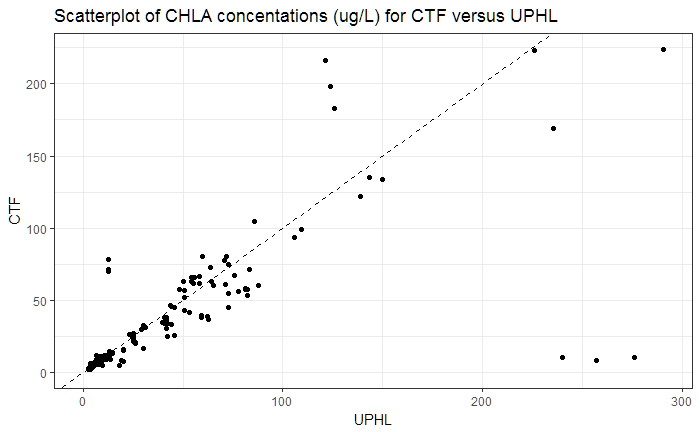

```r
library(ggplot2)
plot.dat <- CHLA.dat1[CHLA.dat1$PARAM == "CHLA",]; # add refinements
plot.dat <- plot.dat[(plot.dat$MLID != 4917320),]
plot.dat <- plot.dat[(plot.dat$MLID != 4930009),]
# cast the data by LAb
plot.dat2 <- reshape2::dcast(plot.dat, MLID + month + PARAM + SK1 + REP ~ Lab,
                             value.var = "CHL_result",
                             fun.aggregate=function(x) mean(x, na.rm=TRUE))
#
z <- ggplot(data = plot.dat2, aes(x = UPHL, y = CTF), na.rm=TRUE)
z1 <- z + geom_point(aes(), na.rm=TRUE) +
    geom_abline(slope = 1, intercept = 0, lty=2, col = "black") +
    theme_bw() + scale_x_continuous(limits= c(0,NA)) +
    scale_y_continuous(limits=c(0,NA)) +
    ggtitle("Scatterplot of CHLA concentations (ug/L) for CTF versus UPHL")
z1
```

**Of course, not really kosher to compare “reps” between lab samples**

#### 2.6 Compare Aggregated CHL results

**Better to compare ‘aggregated’ results by Lab and Parameter (= CHLA)**

Working datafile :: `Lab_summ1` (see Sect. 2.3)

```r
# facet by SITE (MLID)
# Lab = colors or groups
# dates is x-axis
CHLA_ag.dat1 <- Lab_summ1[Lab_summ1$PARAM == "CHLA",]
## drop EQBK 4930009 & 4917320 (duplicate sampledonly once)
CHLA_ag.dat1 <- CHLA_ag.dat1[CHLA_ag.dat1$MLID != 4930009 & CHLA_ag.dat1$MLID != 4917320,]
```

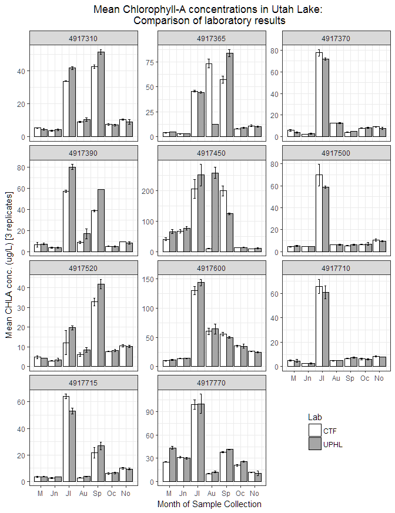

```r
## set up packages
library(ggplot2)
library(scales)
###
##
z <- ggplot(data = CHLA_ag.dat1, aes(x = ((month)), y = mean, fill=Lab),
            na.rm=TRUE) + theme_bw() +
    scale_fill_manual(values=c("white", "gray65")) +
    facet_wrap(~MLID, ncol=3, scales="free_y")
z1 <- z + geom_col(na.rm = TRUE, position=position_dodge(),
                   col="black", width = 0.9) +
        geom_errorbar(aes(ymin=mean-sd, ymax=mean+sd), width = 0.3,
                          position = position_dodge(0.9), na.rm=TRUE) +
    xlab("Month of Sample Collection") + ylab("Mean CHLA conc. (ug/L) [3 replicates]") + ggtitle("Mean Chlorophyll-A concentrations in Utah Lake: \nComparison of laboratory results") +
    theme(plot.title = element_text(hjust = 0.5),
          legend.position=c(0.88,0.07), legend.justification = c(1,0)) +
    scale_x_continuous(breaks = c(5,6,7,8,9,10,11),
                    labels=c("M", "Jn", "Jl", "Au", "Sp", "Oc","No"))
z1
```

```r
# cast data [CHLA_ag.dat1] by Lab
CHLA_ag.dat1_melt <- reshape2::melt(CHLA_ag.dat1, id.vars = c(1:4,9), measure.vars = c(5:8), variable.name = "VAR-x")
CHLA_ag.dat1_melt$LabVar <- paste(CHLA_ag.dat1_melt$Lab, CHLA_ag.dat1_melt$`VAR-x`, sep=".")
# re-cast
CHLA_ag.dat2 <- reshape2::dcast(CHLA_ag.dat1_melt[,c(1:4, 7, 8)], MLID + month + PARAM ~ LabVar, value.var = "value")
```

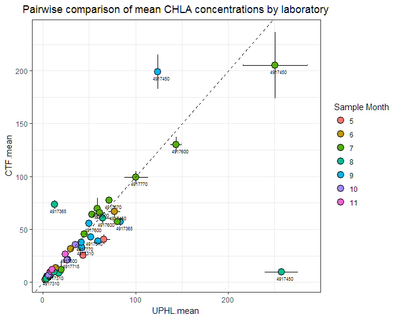

```r
library(ggplot2)
library(scales)
#
q <- ggplot(data = CHLA_ag.dat2, aes(x = UPHL.mean, y = CTF.mean), na.rm=TRUE) +
    theme_bw() + scale_colour_manual(values=rainbow(4))
q1 <- q + geom_errorbar(aes(ymin=CTF.mean-CTF.sd, ymax=CTF.mean+CTF.sd, width=0.3), na.rm=TRUE) +
    geom_errorbarh(aes(xmin=UPHL.mean-UPHL.sd, xmax=UPHL.mean+UPHL.sd, height=0.3), na.rm=TRUE) +
    geom_point(aes(fill=factor(month)), na.rm=T, shape=21, size=4) +
    geom_abline(slope=1, intercept=0, lty=2, col="black") +
    scale_x_continuous(limits= c(NA,NA)) +
    scale_y_continuous(limits=c(NA,NA)) +
    geom_text(aes(label=MLID), size=2, vjust=2, hjust=0.5, na.rm=T, check_overlap = TRUE,
              nudge_x=4) +
    ggtitle("Pairwise comparison of mean CHLA concentrations by laboratory") +
    theme(plot.title = element_text(hjust = 0.5)) +
    labs(fill = "Sample Month")

q1
```

#### 2.7 Aggregated Data Summary

```r
CHLA_ag.dat2$mean_Diff <- CHLA_ag.dat2$CTF.mean - CHLA_ag.dat2$UPHL.mean
CHLA_ag.dat2$mean_LAB <- rowMeans(CHLA_ag.dat2[,c("CTF.mean", "UPHL.mean")])
CHLA_ag.dat2$mean_RSD <- round(abs(CHLA_ag.dat2$mean_Diff)/(CHLA_ag.dat2$mean_LAB), digits=3)*100
```

#### 2.8 Export

**Export datafiles for review**

```r
exp.files <- list("Lab_summary" = Lab_summ1, "CHL_data" = CHLA.dat1, "Lab_comparison" = CHLA_ag.dat2)
#
openxlsx::write.xlsx(exp.files, file = paste("UTLK_CHLA_MethodComparison_export01",
                format(Sys.Date(), "%y%m%d"), ".xlsx", sep=""))
```

### 3.0 DATA CLEANUP TASKS

*Things to do / check / revise while lab and field data continue to accumulate*

**Start work date ::** 170929  
**Last work date ::** 180130  
**Current work / review date ::** 180213

eof